# Practical Machine Learning Course

Andres Lopez

September 2nd, 2019

# 1. Introduction

This is a notebook for the project included in the course “Practical Machine Learning”. We have several data inputs from *health devices*, collecting data from accelerometers on the belt, forearm, arm, and dumbell from several users.

# 2. Load the libraries for the exploratory analysis

```r
library(caret)
```

```r
library(ggplot2)
library(forecast)
library(randomForest)
library(readr)
library(ISLR)
library(dplyr)
library(skimr)
library(lubridate)
library(tidyr)
```

# 3. Load data

The fist step is load the training data, used for creating our model, and the testing data, used to test our model after its creation.

```r
pml_training <- read_csv("pml-training.csv")
pml_testing <- read_csv("pml-testing.csv")
```

# 4. First view of the data

After a first view of the training data, there are a lot of columns with *NA* value on a lot of the data records. I will create a subset of the data removing these columns from the training data, to keep the relevant data for the prediction model.

```r
skim(pml_training)

training <- subset(pml_training,select = c(X1,user_name,cvtd_timestamp,gyros_belt_x,gyros_belt_y,gyros_belt_z,accel_belt_x,accel_belt_y,accel_belt_z,magnet_belt_x,magnet_belt_y,magnet_belt_z,
gyros_arm_x,gyros_arm_y,gyros_arm_z,accel_arm_x,accel_arm_y,accel_arm_z,magnet_arm_x,magnet_arm_y,magnet_arm_z, gyros_dumbbell_x,gyros_dumbbell_y,gyros_dumbbell_z,accel_dumbbell_x,accel_dumbbell_y,accel_dumbbell_z,magnet_dumbbell_x,magnet_dumbbell_y,magnet_dumbbell_z,
gyros_forearm_x,gyros_forearm_y,gyros_forearm_z,accel_forearm_x,accel_forearm_y,accel_forearm_z,magnet_forearm_x,magnet_forearm_y,magnet_forearm_z,classe))

skim(training)
```

[output not shown]

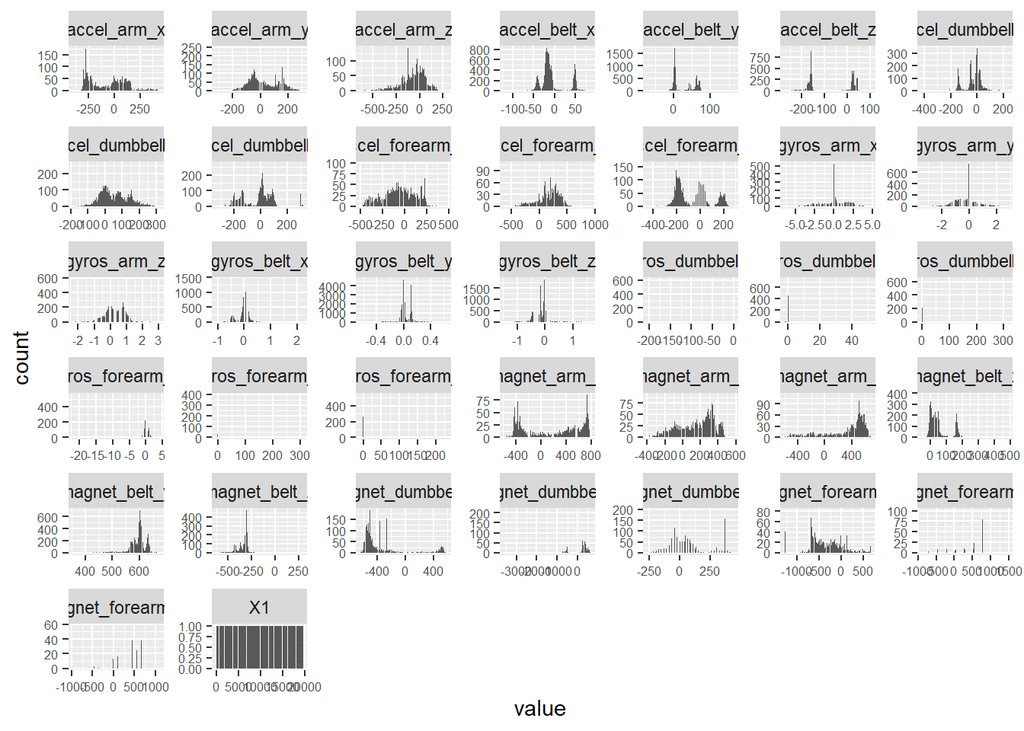

```r
training %>%
  select_if(is.numeric) %>%
  gather() %>%
  ggplot(aes(value)) + geom_bar() + facet_wrap(~key,scales='free') +
  theme(axis.text=element_text(size=6))
```

I will change the type of some of the variables to manage them better. The **classe** variable is changed to factor data type and the **cvtd_timestamp** variable is change to time data type.

```r
training <- training %>%
  mutate(classe = as.factor(classe),
         cvtd_timestamp = as.Date(cvtd_timestamp))
```

# 5. Finding correlations between data

A matrix with correlations are made to check correlations between variables:

```r
training %>%
  select_if(is.numeric) %>%
  cor() %>%
  round(digits = 1)
```

[output not shown]

*End of document*